# FL_Bstate Calculator

# Setup

Below are simply packages used to generate this markdown.

```r
library(dplyr)
library(reshape2)
library(ggplot2)
library(magrittr)
library(ComplexHeatmap)
library(RColorBrewer)
library(circlize)
library(viridis)
```

# Package overview

## Basic Functionality

Read in the existing package gene expression values and the signature necessary to run the function.

```r
data("test_exp")
data("signature_mat")
```

The package requires normalized gene expression values. The methodology will automatically detect if a log transformation has been applied and adjusts accordingly. The gene expression values can be from light based or sequencing based technologies. The signature matrix is derived from RNAseq TPM values, so batch correction is advised when using other technologies. The row names need to be either Hugo symbols or ensembl gene IDs. If you do not have those values, you will need to convert your input to have them.

The input data looks like this…

```r
head(test_exp[, 1:6])
```

```
##                   MC10109  MC10338     MC107   MC10820    MC1103   MC11044
## ENSG00000153253 0.9331593 3.603365 24.210352 1.5685521 1.6906586 0.5730958
## ENSG00000007264 1.4733145 3.208685  6.325099 1.0131143 3.2226782 1.1875892
## ENSG00000251513 1.0745288 2.916929  7.161740 1.4038951 1.3532536 0.3918259
## ENSG00000164056 3.0384653 3.103127  5.407523 0.5410719 1.4286051 0.7977409
## ENSG00000107679 1.1512979 1.243452  2.974582 0.5985688 0.7586875 0.8201129
## ENSG00000142185 4.1904085 2.867111  8.763975 1.3904405 3.6187677 1.7812446
```

Running the function looks like this…

```r
temp_df <- Coef_predictor(test_exp, nu = 0.1, batch_correct = FALSE)
```

It isn’t recommended to mess with the nu value unless you are familiar with SVR and what changing the nu value means. The default value is set to the optimum for this study. As was mentioned, the batch correction is for non-RNA-Seq data.

This dataset generated the signature, so we can observe the prediction accuracy from the prior values calculated from the original NMF.

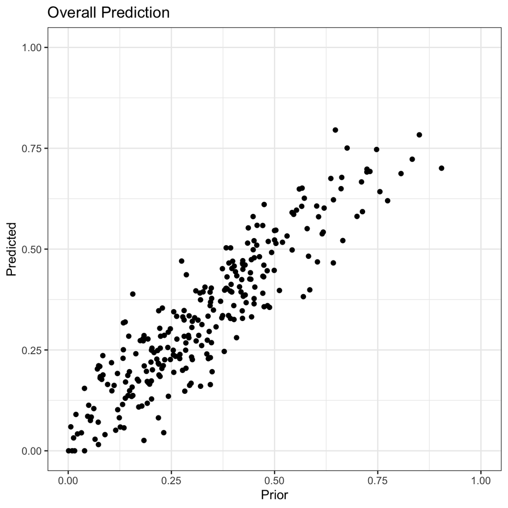

```r
coef_prior <- read.delim("./data/Test_data_coef.txt", sep = "\t") %>%
    apply(1, function(x) x/sum(x)) %>%
    t()

data.frame(Prior = melt(coef_prior)$value, Predicted = melt(temp_df)$value) %>%
    ggplot() + aes(x = Prior, y = Predicted) + geom_point() + lims(x = c(0, 1), y = c(0,
    1)) + labs(title = "Overall Prediction") + theme_bw()
```

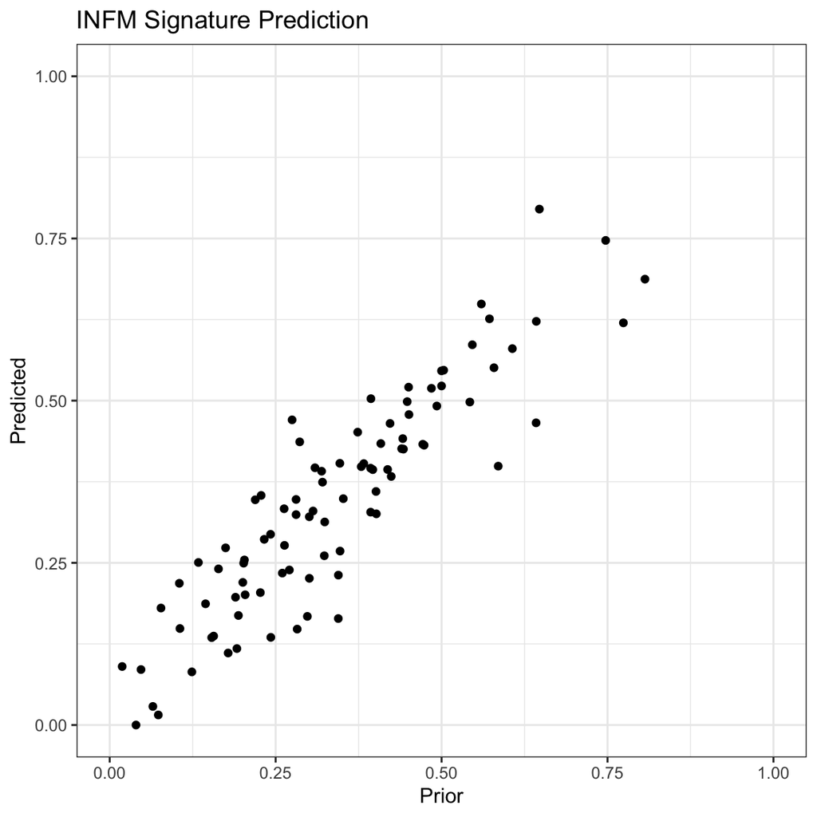

```r
data.frame(Prior = coef_prior[, 1], Predicted = temp_df[, 1]) %>%
    ggplot() + aes(x = Prior, y = Predicted) + geom_point() + lims(x = c(0, 1), y = c(0,
    1)) + labs(title = "INFM Signature Prediction") + theme_bw()
```

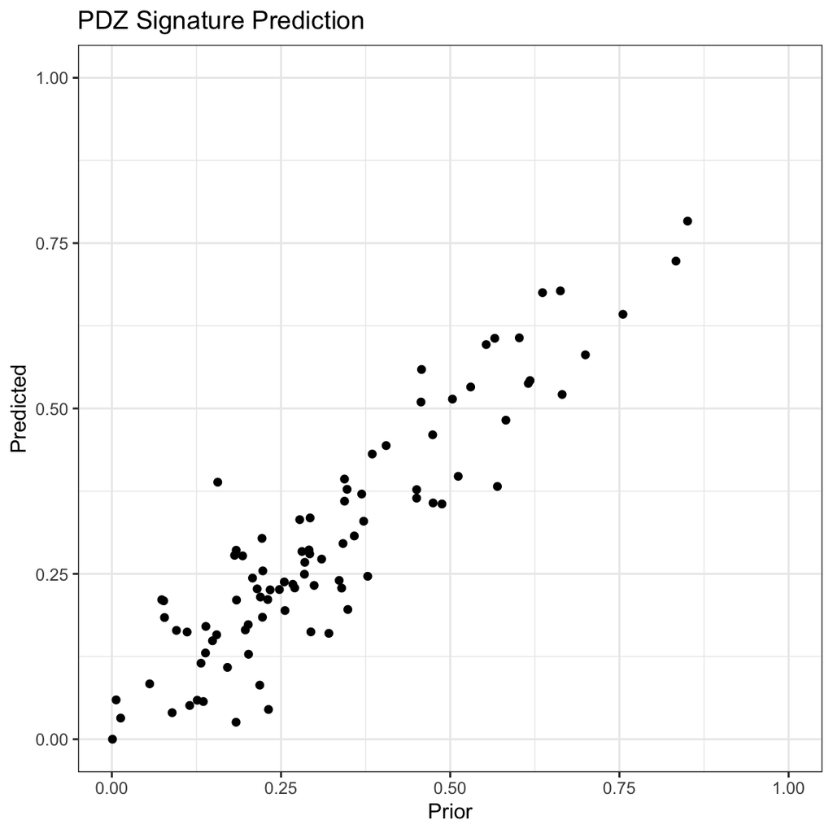

```r
data.frame(Prior = coef_prior[, 2], Predicted = temp_df[, 2]) %>%
    ggplot() + aes(x = Prior, y = Predicted) + geom_point() + lims(x = c(0, 1), y = c(0,
    1)) + labs(title = "PDZ Signature Prediction") + theme_bw()
```

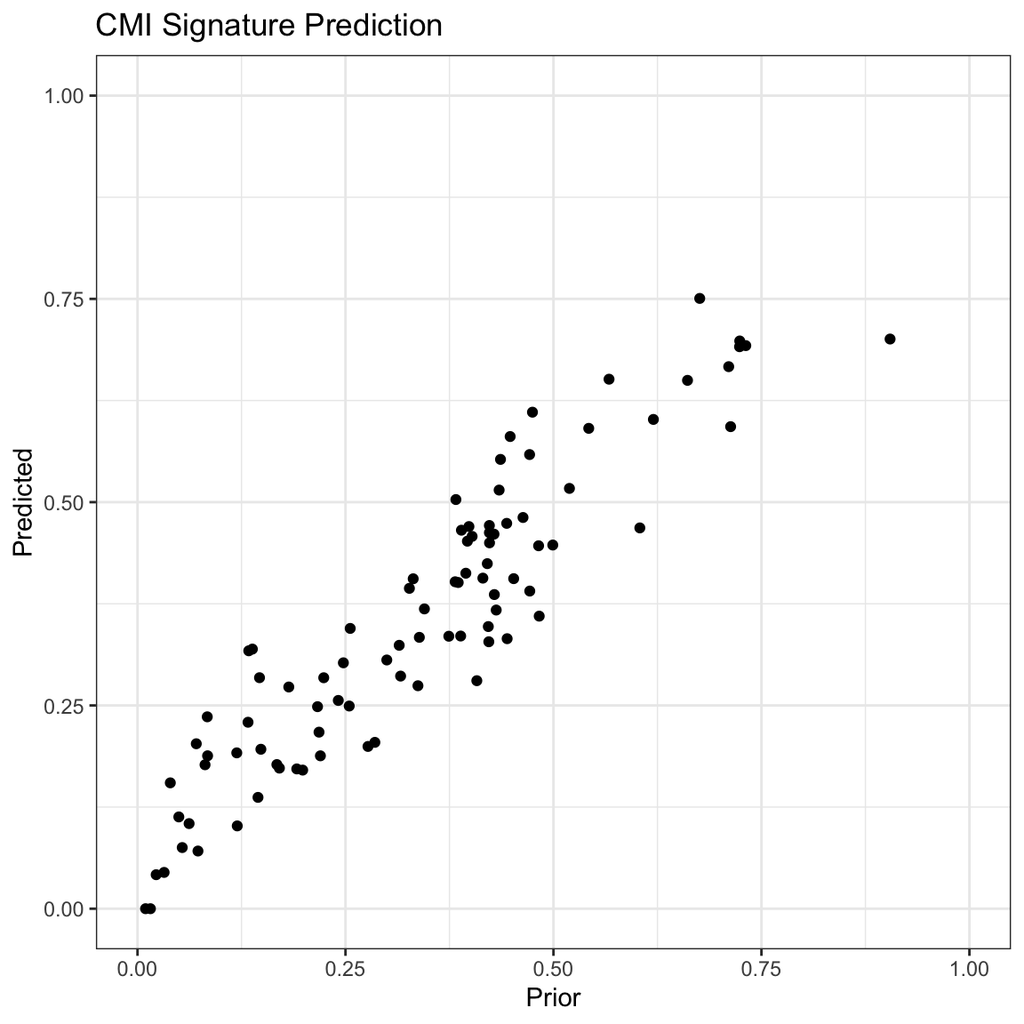

```r
data.frame(Prior = coef_prior[, 3], Predicted = temp_df[, 3]) %>%
    ggplot() + aes(x = Prior, y = Predicted) + geom_point() + lims(x = c(0, 1), y = c(0,
    1)) + labs(title = "CMI Signature Prediction") + theme_bw()
```

You can also use an additional function to predict the class label. Once you’ve predicted the state values, you can use this function to predict the dominant signature.

```r
predict_class(temp_df)
```

```
## MC10109 MC10338   MC107 MC10820  MC1103 MC11044  MC1643  MC1658  MC1915  MC2001
##   "CMI"   "CMI"  "INFM"   "PDZ"   "CMI"   "CMI"   "CMI"   "CMI"  "INFM"   "CMI"
##  MC2003  MC2225  MC2391  MC2475  MC2510  MC2636  MC2687  MC2769   MC277  MC2859
##   "PDZ"   "CMI"  "INFM"  "INFM"  "INFM"   "CMI"   "CMI"   "CMI"   "CMI"   "CMI"
##  MC2899  MC2999  MC3059  MC3222  MC3495  MC3693  MC3760  MC3776  MC3807   MC383
##   "CMI"   "CMI"   "PDZ"   "PDZ"   "PDZ"  "INFM"   "PDZ"   "PDZ"  "INFM"  "INFM"
##  MC3848  MC3892  MC4033  MC4205  MC4221   MC438  MC4566  MC4718   MC475   MC481
##   "PDZ"   "CMI"   "PDZ"   "CMI"   "PDZ"   "CMI"   "CMI"   "PDZ"   "CMI"   "PDZ"
##  MC4975  MC4999  MC5041  MC5433  MC5507  MC5626  MC5627  MC5828  MC5844  MC5933
##  "INFM"  "INFM"   "PDZ"  "INFM"   "PDZ"  "INFM"   "PDZ"  "INFM"   "PDZ"   "CMI"
##  MC5967   MC598  MC5980  MC6210  MC6540  MC6617  MC6864    MC73  MC7866  MC8071
##   "CMI"   "PDZ"   "PDZ"   "CMI"  "INFM"   "PDZ"   "PDZ"   "CMI"   "CMI"   "CMI"
##  MC8178  MC8211  MC8227  MC8453    MC85  MC8628   MC867  MC9008   MC936  MF1065
##   "CMI"  "INFM"   "PDZ"  "INFM"   "PDZ"  "INFM"   "PDZ"   "CMI"   "CMI"   "CMI"
##  MF1155  MF1536  MF1733  MF1957  MF2128  MF2480  MF2513  MF2981  MF3375   MF386
##   "CMI"  "INFM"   "CMI"   "PDZ"  "INFM"  "INFM"  "INFM"   "PDZ"  "INFM"   "CMI"
##  MF4209  MF4321  MF4463  MF4464  MF4472  MF4510  MF4539  MF4555  MF4587  MF4663
##   "CMI"  "INFM"  "INFM"  "INFM"   "CMI"  "INFM"   "CMI"  "INFM"  "INFM"   "PDZ"
##   MF840
##   "CMI"
```

Thats it!

# External Example

```r
GSE127462_exp <- read.csv("./data/GSE127462_exp_avg.csv", row.names = 1)
```

Predict the B cell states and class labels.

```r
GSE127462_pred <- Coef_predictor(GSE127462_exp, batch_correct = TRUE)
GSE127462_class <- predict_class(GSE127462_pred)

GSE127462_pred <- lapply(c("INFM", "PDZ", "CMI"), function(x) GSE127462_pred[grep(x,
    GSE127462_class), ] %>%
    .[order(.[, x], decreasing = TRUE), ]) %>%
    do.call(rbind, .)

GSE127462_class <- GSE127462_class[rownames(GSE127462_pred)]
```

Plot the results.

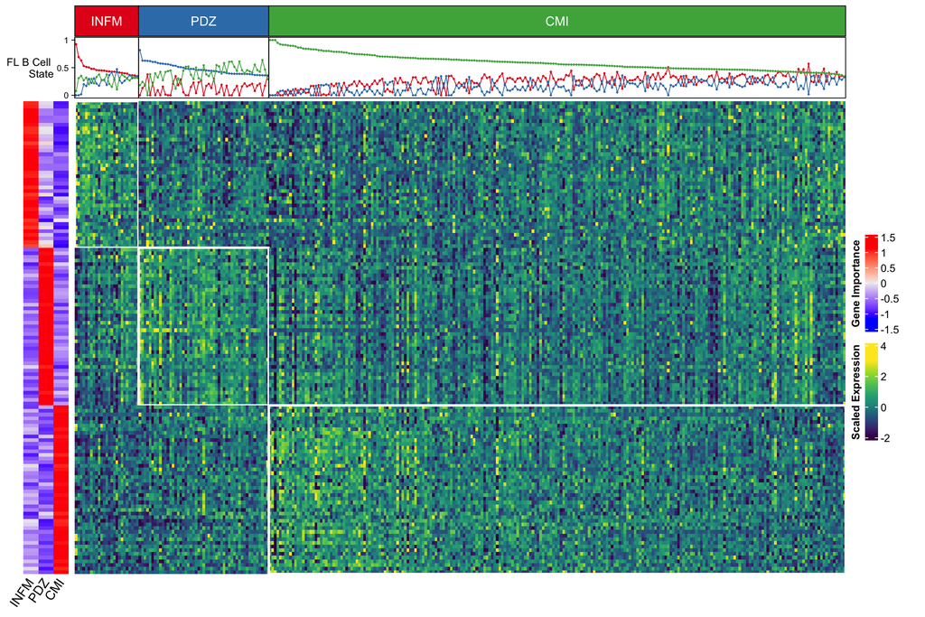

```r
supplemental_fig_gen(GSE127462_exp, sig_mat_opt = "GeneName", GSE127462_pred, GSE127462_class)
```